# Python Note 2

### 1.d.3 Statistics Analysis

And produce descriptive statistics for each scenario,  
specifically the minimum, mean, and maximum totals after each game.  
What do you observe about the winning and losing totals?**

```python
print('Winner total score min: {}'.format(report_array[:,9].min()))
print('Winner total score max: {}'.format(report_array[:,9].max()))
print('Winner total score mean: {}'.format(report_array[:,9].mean()))
print('Loser total score min: {}'.format(report_array[:,11].min()))
print('Loser total score max: {}'.format(report_array[:,11].max()))
print('Loser total score mean: {}'.format(report_array[:,11].mean()))
```

[output not shown]

**What proportion of games resulted in a winner that had a lower initial total than their opponent?**

```python
(report_array[:,8] < max_total/2).mean()
```

[output not shown]

**What was the lowest initial total to win a game?**

```python
report_array[:,8].min()
```

[output not shown]

**(Or conversely, the highest initial total to lose a game)?**

```python
report_array[:,10].max()
```

[output not shown]

**Response:**  
The player who has higher initial total is more liely to win the game in the end.

Calculate the (linear) correlation between the initial and final totals for winners vs. losers?  
What do you observe about the respective correlations,  
and what do these correlations tell you about the relationship between the initial and final totals?

Winners:

```python
winner_init = report_array[:,8]
winner_final = report_array[:,9]
```

```python
np.corrcoef(winner_init,winner_final)
```

```
array([[1.        , 0.60864055],
       [0.60864055, 1.        ]])
```

Losers:

```python
np.corrcoef(report_array[:,10],report_array[:,11])
```

```
array([[1.        , 0.53511042],
       [0.53511042, 1.        ]])
```

## Extra Analysis

**Note**: The following is some extra analysis work, not required in the assignment

```python
import matplotlib
import matplotlib.pyplot as plt
```

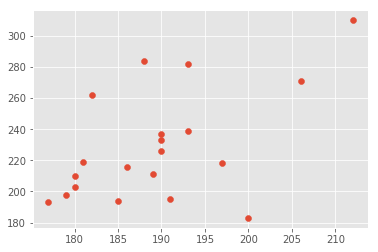

```python
%matplotlib inline
matplotlib.style.use('ggplot')

plt.scatter(winner_init,winner_final)
plt.show()
```

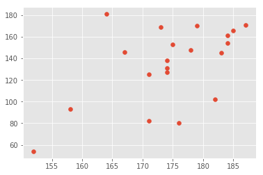

```python
plt.scatter(report_array[:,10],report_array[:,11])
plt.show()
```

```python
final_player1_win_count = sum(report_array[:,5])
final_player2_win_count = sum(report_array[:,6])
final_tie_count = sum(report_array[:,7])
print("Player 1 win {} out of {} games.".format(final_player1_win_count,game_round))
print("Player 2 win {} out of {} games.".format(final_player2_win_count,game_round))
print("Players tie {} out of {} games.".format(final_tie_count,game_round))
```

```
Player 1 win 10 out of 20 games.
Player 2 win 10 out of 20 games.
Players tie 0 out of 20 games.
```

```python
import pandas
```

```python
df=pandas.DataFrame.from_dict(report_list)
```

```python
print(df['final_player1_win'].mean())
print(df['final_player2_win'].mean())
print(df['final_tie'].mean())
```

```
0.5
0.5
0.0
```

```python
df.info()
```

```
<class 'pandas.core.frame.DataFrame'>
RangeIndex: 20 entries, 0 to 19
Data columns (total 12 columns):
final_player1_win    20 non-null bool
final_player2_win    20 non-null bool
final_tie            20 non-null bool
final_winner         20 non-null int64
loser_initial        20 non-null int64
loser_total          20 non-null int64
player1_initial      20 non-null int64
player1_total_win    20 non-null int64
player2_initial      20 non-null int64
player2_total_win    20 non-null int64
winner_initial       20 non-null int64
winner_total         20 non-null int64
dtypes: bool(3), int64(9)
memory usage: 1.5 KB
```

```python
df
```

|  | final_player1_win | final_player2_win | final_tie | final_winner | loser_initial | loser_total | player1_initial | player1_total_win | player2_initial | player2_total_win | winner_initial | winner_total |
| --- | --- | --- | --- | --- | --- | --- | --- | --- | --- | --- | --- | --- |
| 0 | False | True | False | 2 | 158 | 93 | 158 | 93 | 206 | 271 | 206 | 271 |
| 1 | False | True | False | 2 | 167 | 146 | 167 | 146 | 197 | 218 | 197 | 218 |
| 2 | True | False | False | 1 | 179 | 170 | 185 | 194 | 179 | 170 | 185 | 194 |
| 3 | True | False | False | 1 | 184 | 161 | 180 | 203 | 184 | 161 | 180 | 203 |
| 4 | True | False | False | 1 | 178 | 148 | 186 | 216 | 178 | 148 | 186 | 216 |
| 5 | True | False | False | 1 | 174 | 131 | 190 | 233 | 174 | 131 | 190 | 233 |
| 6 | False | True | False | 2 | 174 | 127 | 174 | 127 | 190 | 237 | 190 | 237 |
| 7 | True | False | False | 1 | 171 | 82 | 193 | 282 | 171 | 82 | 193 | 282 |
| 8 | False | True | False | 2 | 173 | 169 | 173 | 169 | 191 | 195 | 191 | 195 |
| 9 | False | True | False | 2 | 164 | 181 | 164 | 181 | 200 | 183 | 200 | 183 |
| 10 | False | True | False | 2 | 182 | 102 | 182 | 102 | 182 | 262 | 182 | 262 |
| 11 | True | False | False | 1 | 174 | 138 | 190 | 226 | 174 | 138 | 190 | 226 |
| 12 | True | False | False | 1 | 175 | 153 | 189 | 211 | 175 | 153 | 189 | 211 |
| 13 | True | False | False | 1 | 185 | 166 | 179 | 198 | 185 | 166 | 179 | 198 |
| 14 | False | True | False | 2 | 187 | 171 | 187 | 171 | 177 | 193 | 177 | 193 |
| 15 | False | True | False | 2 | 176 | 80 | 176 | 80 | 188 | 284 | 188 | 284 |
| 16 | True | False | False | 1 | 184 | 154 | 180 | 210 | 184 | 154 | 180 | 210 |
| 17 | False | True | False | 2 | 183 | 145 | 183 | 145 | 181 | 219 | 181 | 219 |
| 18 | True | False | False | 1 | 152 | 54 | 212 | 310 | 152 | 54 | 212 | 310 |
| 19 | False | True | False | 2 | 171 | 125 | 171 | 125 | 193 | 239 | 193 | 239 |